# 项目介绍

所谓探索性数据分析(Exploratory Data Analysis，以下简称EDA)，是指对已有的数据(特别是调查或观察得来的原始数据)在尽量少的先验假定下进行探索，通过作图、制表、方程拟合、计算特征量等手段探索数据的结构和规律的一种数据分析方法。特别是当我们对这些数据中的信息没有足够的经验，不知道该用何种传统统计方法进行分析时，探索性数据分析就会非常有效。探索性数据分析在上世纪六十年代被提出，其方法由美国著名统计学家约翰·图基(John Tukey)命名。

# 项目目标

- 利率与风险成正比，找出影响风险的因素有哪些？
- 了解p2p平台的业务特点，产品类型，资产质量等？
- 有什么建议

# 项目背景

Lending Club 是全球最大的撮合借款人和投资人的线上金融平台，它利用互联网模式建立了一种比传统银行系统更有效率的、能够在借款人和投资人之间自由配置资本的机制。 通过Lending Club 的平台，借款人和小微企业可以获得更低的利率，投资人则可以获得较好的收益。

公司于2006 年10 月在特拉华州以“SocBank”的名字成立，之后于2006 年11 月更名为Lending Club。

截至 2014 年6 月30 日，Lending Club 累计贷款金额超过50 亿美元，支付给投资人的利息超过4.9 亿美元。

### 数据集

数据集是Lending Club平台发生借贷的业务数据（2018第一季）

数据集中主要特征含义

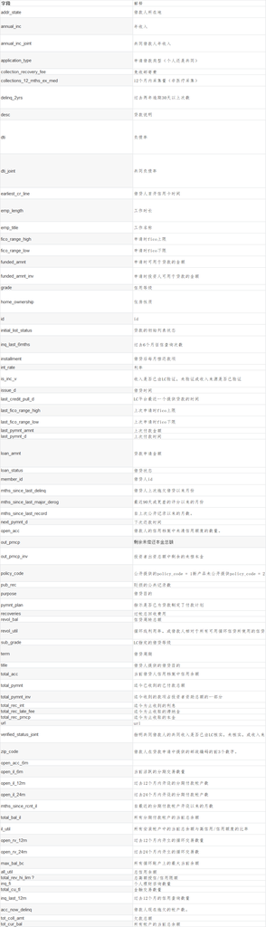

## 前期准备

### 第一步，导入我们要用的库

```python
import pandas as pd
import numpy as np
import matplotlib.pyplot as plt
plt.style.use('ggplot')
import seaborn as sns
sns.set_style('whitegrid')
%matplotlib inline

import warnings
warnings.filterwarnings('ignore')

plt.rcParams['font.sans-serif'] = ['SimHei']
plt.rcParams['axes.unicode_minus'] = False # 解决保存图像是负号显示为方块的问题
```

## 获取数据

### 第二步，解析数据

```python
data = pd.read_csv('LoanStats_2018Q1.csv')
```

## 探索分析数据（EDA）

获得数据后就要合理的检查数据。例如：数据是否重复；数据是什么类型；数据是否有意义；有什么删除的吗？此外，可能还有异常值。同时，我们要对数据进行简单的统计测试，并可视化。EDA非常关键。

```python
data.shape
# 数据有107868行，145列
```

```
(107868, 145)
```

```python
data.head()
```

|  | id | member_id | loan_amnt | funded_amnt | funded_amnt_inv | term | int_rate | installment | grade | sub_grade | ... | hardship_payoff_balance_amount | hardship_last_payment_amount | disbursement_method | debt_settlement_flag | debt_settlement_flag_date | settlement_status | settlement_date | settlement_amount | settlement_percentage | settlement_term |
| --- | --- | --- | --- | --- | --- | --- | --- | --- | --- | --- | --- | --- | --- | --- | --- | --- | --- | --- | --- | --- | --- |
| 0 | NaN | NaN | 18500.0 | 18500.0 | 18500.0 | 36 months | 13.58% | 628.52 | C | C2 | ... | NaN | NaN | Cash | N | NaN | NaN | NaN | NaN | NaN | NaN |
| 1 | NaN | NaN | 7000.0 | 7000.0 | 7000.0 | 36 months | 7.34% | 217.23 | A | A4 | ... | NaN | NaN | Cash | N | NaN | NaN | NaN | NaN | NaN | NaN |
| 2 | NaN | NaN | 16000.0 | 16000.0 | 16000.0 | 60 months | 11.98% | 355.75 | B | B5 | ... | NaN | NaN | Cash | N | NaN | NaN | NaN | NaN | NaN | NaN |
| 3 | NaN | NaN | 28000.0 | 28000.0 | 28000.0 | 36 months | 10.90% | 915.36 | B | B4 | ... | NaN | NaN | Cash | N | NaN | NaN | NaN | NaN | NaN | NaN |
| 4 | NaN | NaN | 8300.0 | 8300.0 | 8300.0 | 36 months | 7.34% | 257.58 | A | A4 | ... | NaN | NaN | Cash | N | NaN | NaN | NaN | NaN | NaN | NaN |

5 rows × 145 columns

```python
data.iloc[0]
```

```
id                                                         NaN
member_id                                                  NaN
loan_amnt                                                18500
funded_amnt                                              18500
funded_amnt_inv                                          18500
term                                                 36 months
int_rate                                                13.58%
installment                                             628.52
grade                                                        C
sub_grade                                                   C2
emp_title                                              Teacher
emp_length                                             6 years
home_ownership                                        MORTGAGE
annual_inc                                               82985
verification_status                               Not Verified
issue_d                                                 Mar-18
loan_status                                            Current
pymnt_plan                                                   n
url                                                        NaN
desc                                                       NaN
purpose                                       home_improvement
title                                         Home improvement
zip_code                                                 070xx
addr_state                                                  NJ
dti                                                      18.66
delinq_2yrs                                                  1
earliest_cr_line                                        Apr-04
inq_last_6mths                                               0
mths_since_last_delinq                                      11
mths_since_last_record                                      97
                                                    ...
sec_app_open_acc                                           NaN
sec_app_revol_util                                         NaN
sec_app_open_act_il                                        NaN
sec_app_num_rev_accts                                      NaN
sec_app_chargeoff_within_12_mths                           NaN
sec_app_collections_12_mths_ex_med                         NaN
sec_app_mths_since_last_major_derog                        NaN
hardship_flag                                                N
hardship_type                                              NaN
hardship_reason                                            NaN
hardship_status                                            NaN
deferral_term                                              NaN
hardship_amount                                            NaN
hardship_start_date                                        NaN
hardship_end_date                                          NaN
payment_plan_start_date                                    NaN
hardship_length                                            NaN
hardship_dpd                                               NaN
hardship_loan_status                                       NaN
orig_projected_additional_accrued_interest                 NaN
hardship_payoff_balance_amount                             NaN
hardship_last_payment_amount                               NaN
disbursement_method                                       Cash
debt_settlement_flag                                         N
debt_settlement_flag_date                                  NaN
settlement_status                                          NaN
settlement_date                                            NaN
settlement_amount                                          NaN
settlement_percentage                                      NaN
settlement_term                                            NaN
Name: 0, Length: 145, dtype: object
```

由上图发现有一些列有许多缺失值，这些缺失值对我们没有用处，因此，首先把有许多缺失值得列删除，同时保存为新csv

### 处理缺失值

统计每列属性缺失值的数量

```python
def not_null_count(column):
    column_null = pd.isnull(column)
    null = column[column_null]
    return len(null)

column_null_count = data.apply(not_null_count)
print(column_null_count)
```

```
id                                            107866
member_id                                     107868
loan_amnt                                          4
funded_amnt                                        4
funded_amnt_inv                                    4
term                                               4
int_rate                                           4
installment                                        4
grade                                              4
sub_grade                                          4
emp_title                                       9617
emp_length                                      9432
home_ownership                                     4
annual_inc                                         4
verification_status                                4
issue_d                                            4
loan_status                                        4
pymnt_plan                                         4
url                                           107868
desc                                          107868
purpose                                            4
title                                              4
zip_code                                           4
addr_state                                         4
dti                                              266
delinq_2yrs                                        4
earliest_cr_line                                   4
inq_last_6mths                                     4
mths_since_last_delinq                         60699
mths_since_last_record                         92599
                                               ...
sec_app_open_acc                               91537
sec_app_revol_util                             91847
sec_app_open_act_il                            91537
sec_app_num_rev_accts                          91537
sec_app_chargeoff_within_12_mths               91537
sec_app_collections_12_mths_ex_med             91537
sec_app_mths_since_last_major_derog           102441
hardship_flag                                      4
hardship_type                                 107868
hardship_reason                               107868
hardship_status                               107868
deferral_term                                 107868
hardship_amount                               107868
hardship_start_date                           107868
hardship_end_date                             107868
payment_plan_start_date                       107868
hardship_length                               107868
hardship_dpd                                  107868
hardship_loan_status                          107868
orig_projected_additional_accrued_interest    107868
hardship_payoff_balance_amount                107868
hardship_last_payment_amount                  107868
disbursement_method                                4
debt_settlement_flag                               4
debt_settlement_flag_date                     107862
settlement_status                             107862
settlement_date                               107862
settlement_amount                             107862
settlement_percentage                         107862
settlement_term                               107862
Length: 145, dtype: int64
```

```python
half_count = len(data)/2 #设定阈值
data = data.dropna(thresh=half_count,axis=1)# 若某一列数据缺失的数量超过阈值就被删除
data.to_csv('loan_2018q1.csv',index=False)
```

```python
loans = pd.read_csv('loan_2018q1.csv')
print(loans.shape)
loans.head()
```

```
(107868, 102)
```

|  | loan_amnt | funded_amnt | funded_amnt_inv | term | int_rate | installment | grade | sub_grade | emp_title | emp_length | ... | percent_bc_gt_75 | pub_rec_bankruptcies | tax_liens | tot_hi_cred_lim | total_bal_ex_mort | total_bc_limit | total_il_high_credit_limit | hardship_flag | disbursement_method | debt_settlement_flag |
| --- | --- | --- | --- | --- | --- | --- | --- | --- | --- | --- | --- | --- | --- | --- | --- | --- | --- | --- | --- | --- | --- |
| 0 | 18500.0 | 18500.0 | 18500.0 | 36 months | 13.58% | 628.52 | C | C2 | Teacher | 6 years | ... | 0.0 | 1.0 | 0.0 | 100830.0 | 53116.0 | 27400.0 | 61030.0 | N | Cash | N |
| 1 | 7000.0 | 7000.0 | 7000.0 | 36 months | 7.34% | 217.23 | A | A4 | vice president | 10+ years | ... | 0.0 | 0.0 | 0.0 | 410809.0 | 67331.0 | 17900.0 | 129270.0 | N | Cash | N |
| 2 | 16000.0 | 16000.0 | 16000.0 | 60 months | 11.98% | 355.75 | B | B5 | Administrative Assistant | 5 years | ... | 33.3 | 0.0 | 0.0 | 195926.0 | 20005.0 | 13300.0 | 22864.0 | N | Cash | N |
| 3 | 28000.0 | 28000.0 | 28000.0 | 36 months | 10.90% | 915.36 | B | B4 | Corporate Ergonomist | 6 years | ... | 11.1 | 0.0 | 0.0 | 153679.0 | 76475.0 | 80300.0 | 73379.0 | N | Cash | N |
| 4 | 8300.0 | 8300.0 | 8300.0 | 36 months | 7.34% | 257.58 | A | A4 | Admin | 4 years | ... | 33.3 | 0.0 | 0.0 | 237274.0 | 48636.0 | 12000.0 | 53654.0 | N | Cash | N |

5 rows × 102 columns

数据减少至102列

```python
loans.dtypes # 检查数据类型
```

```
loan_amnt                     float64
funded_amnt                   float64
funded_amnt_inv               float64
term                           object
int_rate                       object
installment                   float64
grade                          object
sub_grade                      object
emp_title                      object
emp_length                     object
home_ownership                 object
annual_inc                    float64
verification_status            object
issue_d                        object
loan_status                    object
pymnt_plan                     object
purpose                        object
title                          object
zip_code                       object
addr_state                     object
dti                           float64
delinq_2yrs                   float64
earliest_cr_line               object
inq_last_6mths                float64
open_acc                      float64
pub_rec                       float64
revol_bal                     float64
revol_util                     object
total_acc                     float64
initial_list_status            object
                               ...
mo_sin_rcnt_rev_tl_op         float64
mo_sin_rcnt_tl                float64
mort_acc                      float64
mths_since_recent_bc          float64
mths_since_recent_inq         float64
num_accts_ever_120_pd         float64
num_actv_bc_tl                float64
num_actv_rev_tl               float64
num_bc_sats                   float64
num_bc_tl                     float64
num_il_tl                     float64
num_op_rev_tl                 float64
num_rev_accts                 float64
num_rev_tl_bal_gt_0           float64
num_sats                      float64
num_tl_120dpd_2m              float64
num_tl_30dpd                  float64
num_tl_90g_dpd_24m            float64
num_tl_op_past_12m            float64
pct_tl_nvr_dlq                float64
percent_bc_gt_75              float64
pub_rec_bankruptcies          float64
tax_liens                     float64
tot_hi_cred_lim               float64
total_bal_ex_mort             float64
total_bc_limit                float64
total_il_high_credit_limit    float64
hardship_flag                  object
disbursement_method            object
debt_settlement_flag           object
Length: 102, dtype: object
```

```python
loans.describe()
```

|  | loan_amnt | funded_amnt | funded_amnt_inv | installment | annual_inc | dti | delinq_2yrs | inq_last_6mths | open_acc | pub_rec | ... | num_tl_90g_dpd_24m | num_tl_op_past_12m | pct_tl_nvr_dlq | percent_bc_gt_75 | pub_rec_bankruptcies | tax_liens | tot_hi_cred_lim | total_bal_ex_mort | total_bc_limit | total_il_high_credit_limit |
| --- | --- | --- | --- | --- | --- | --- | --- | --- | --- | --- | --- | --- | --- | --- | --- | --- | --- | --- | --- | --- | --- |
| count | 107864.000000 | 107864.000000 | 107864.000000 | 107864.000000 | 1.078640e+05 | 107602.000000 | 107864.000000 | 107864.000000 | 107864.000000 | 107864.000000 | ... | 107864.000000 | 107864.000000 | 107863.000000 | 106350.000000 | 107864.000000 | 107864.000000 | 1.078640e+05 | 1.078640e+05 | 107864.000000 | 107864.000000 |
| mean | 16147.942780 | 16147.942780 | 16143.857775 | 469.664262 | 7.854227e+04 | 19.648209 | 0.223773 | 0.461266 | 11.377151 | 0.163243 | ... | 0.058333 | 2.001836 | 94.662365 | 32.454015 | 0.123971 | 0.039160 | 1.852063e+05 | 5.093050e+04 | 26957.654806 | 45064.532587 |
| std | 10184.024938 | 10184.024938 | 10182.885389 | 289.225788 | 7.687436e+04 | 21.795902 | 0.730417 | 0.746153 | 5.879388 | 0.494799 | ... | 0.401722 | 1.861591 | 9.036803 | 34.897087 | 0.335350 | 0.352788 | 1.886676e+05 | 5.190748e+04 | 25827.858576 | 47269.256578 |
| min | 1000.000000 | 1000.000000 | 1000.000000 | 30.120000 | 0.000000e+00 | 0.000000 | 0.000000 | 0.000000 | 0.000000 | 0.000000 | ... | 0.000000 | 0.000000 | 0.000000 | 0.000000 | 0.000000 | 0.000000 | 0.000000e+00 | 0.000000e+00 | 0.000000 | 0.000000 |
| 25% | 8000.000000 | 8000.000000 | 8000.000000 | 254.560000 | 4.500000e+04 | 11.230000 | 0.000000 | 0.000000 | 7.000000 | 0.000000 | ... | 0.000000 | 1.000000 | 92.300000 | 0.000000 | 0.000000 | 0.000000 | 5.190800e+04 | 1.909075e+04 | 9800.000000 | 14500.000000 |
| 50% | 14000.000000 | 14000.000000 | 14000.000000 | 389.360000 | 6.500000e+04 | 17.670000 | 0.000000 | 0.000000 | 10.000000 | 0.000000 | ... | 0.000000 | 2.000000 | 100.000000 | 25.000000 | 0.000000 | 0.000000 | 1.176615e+05 | 3.683300e+04 | 19500.000000 | 33206.000000 |
| 75% | 22400.000000 | 22400.000000 | 22375.000000 | 637.840000 | 9.500000e+04 | 25.020000 | 0.000000 | 1.000000 | 14.000000 | 0.000000 | ... | 0.000000 | 3.000000 | 100.000000 | 50.000000 | 0.000000 | 0.000000 | 2.692085e+05 | 6.505125e+04 | 35700.000000 | 61147.250000 |
| max | 40000.000000 | 40000.000000 | 40000.000000 | 1618.030000 | 8.365188e+06 | 999.000000 | 20.000000 | 5.000000 | 69.000000 | 52.000000 | ... | 19.000000 | 20.000000 | 100.000000 | 100.000000 | 4.000000 | 52.000000 | 6.057411e+06 | 1.009178e+06 | 471400.000000 | 921338.000000 |

8 rows × 77 columns

describe()函数不能统计object类型属性，部分数据int_rate,emp_length数据类型都是object，稍后分析要转换为float类型

数据集属性较多，我们初步聚集几个重要特征展开分析。

```python
used_col = ['loan_amnt', 'term', 'int_rate', 'grade', 'issue_d', 'addr_state', 'loan_status','purpose','delinq_2yrs','annual_inc','emp_length']
# 贷款金额、贷款期限、贷款利率、信用评级、业务发生时间、业务发生所在州、贷款状态、贷款用途、2年内违约次数，年收入，工作时长
used_data = loans[used_col]
```

```python
used_data.head()
```

|  | loan_amnt | term | int_rate | grade | issue_d | addr_state | loan_status | purpose | delinq_2yrs | annual_inc | emp_length |
| --- | --- | --- | --- | --- | --- | --- | --- | --- | --- | --- | --- |
| 0 | 18500.0 | 36 months | 13.58% | C | Mar-18 | NJ | Current | home_improvement | 1.0 | 82985.0 | 6 years |
| 1 | 7000.0 | 36 months | 7.34% | A | Mar-18 | IL | Current | debt_consolidation | 1.0 | 180700.0 | 10+ years |
| 2 | 16000.0 | 60 months | 11.98% | B | Mar-18 | WY | Current | home_improvement | 0.0 | 95000.0 | 5 years |
| 3 | 28000.0 | 36 months | 10.90% | B | Mar-18 | NC | Current | debt_consolidation | 0.0 | 103000.0 | 6 years |
| 4 | 8300.0 | 36 months | 7.34% | A | Mar-18 | MO | Current | debt_consolidation | 0.0 | 40000.0 | 4 years |

```python
column_null_count = used_data.apply(not_null_count)
print(column_null_count)#判断某列属性是否存在缺失值
```

```
loan_amnt         4
term              4
int_rate          4
grade             4
issue_d           4
addr_state        4
loan_status       4
purpose           4
delinq_2yrs       4
annual_inc        4
emp_length     9432
dtype: int64
```

### 单变量分析

- 1.贷款状态分布

### 处理异常值

```python
used_data[used_data['loan_status'].isnull()]
```

|  | loan_amnt | term | int_rate | grade | issue_d | addr_state | loan_status | purpose | delinq_2yrs | annual_inc | emp_length |
| --- | --- | --- | --- | --- | --- | --- | --- | --- | --- | --- | --- |
| 107864 | NaN | NaN | NaN | NaN | NaN | NaN | NaN | NaN | NaN | NaN | NaN |
| 107865 | NaN | NaN | NaN | NaN | NaN | NaN | NaN | NaN | NaN | NaN | NaN |
| 107866 | NaN | NaN | NaN | NaN | NaN | NaN | NaN | NaN | NaN | NaN | NaN |
| 107867 | NaN | NaN | NaN | NaN | NaN | NaN | NaN | NaN | NaN | NaN | NaN |

由于loan_status异常值数量较小，因此我们直接删异常值所对应的行

```python
used_data = used_data.dropna()
used_data['loan_status'].value_counts()
```

```
Current               91662
Fully Paid             4988
Late (31-120 days)      745
In Grace Period         590
Late (16-30 days)       345
Charged Off              87
Default                  19
Name: loan_status, dtype: int64
```

为了方便分析，我们将贷款状态进行分类变量编码，主要将贷款状态分为正常和违约

```python
codeDict={'Current':0,'Fully Paid':0,'Late (31-120 days)':1,'In Grace Period':1,'Late (16-30 days)':1,'Charged Off':1,'Default':1}
used_data['loan_status_coded'] = used_data['loan_status'].map(codeDict)
print('After Coding:')
used_data['loan_status_coded'].value_counts()
```

```
After Coding:
```

```
0    96650
1     1786
Name: loan_status_coded, dtype: int64
```

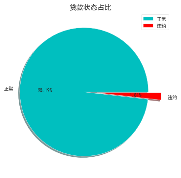

```python
loan_status_values = pd.value_counts(used_data['loan_status_coded']).values
labels = ['正常','违约']
plt.figure(figsize=(6,6))
plt.pie(loan_status_values,explode = [0.1,0.1],
        labels = labels, shadow = True,autopct='%1.2f%%',
        colors = ['c', 'r'])
plt.title('贷款状态占比')
plt.legend()
plt.show()
```

- 2.贷款金额分布

```
贷款金额中位数
14875.0
```

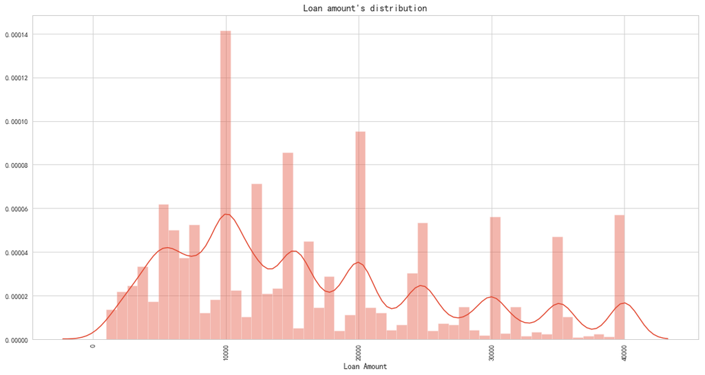

```python
plt.figure(figsize=(18,9))
sdisplot_loan = sns.distplot(used_data['loan_amnt'])
plt.xticks(rotation=90)
plt.xlabel('Loan Amount')
plt.title('Loan amount\'s distribution')
sdisplot_loan.figure.savefig('Loan_amuont')
print('贷款金额中位数')
print(used_data['loan_amnt'].median())
```

- 3.贷款期限分布

```python
used_data['term'].value_counts()
```

```
 36 months    68273
 60 months    30163
Name: term, dtype: int64
```

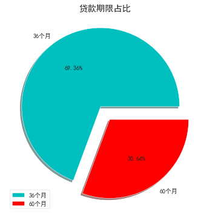

```python
loan_status_values = pd.value_counts(used_data['term']).values
labels = ['36个月','60个月']
plt.figure(figsize=(6,6))
plt.pie(loan_status_values,explode = [0.1,0.1],
        labels = labels, shadow = True,autopct='%1.2f%%',
        colors = ['c', 'r'])
plt.title('贷款期限占比')
plt.legend()
plt.show()
```

- 4.贷款产品用途种类比较

```python
used_data['purpose'].value_counts()
```

```
debt_consolidation    50386
credit_card           22526
other                  8735
home_improvement       6870
major_purchase         3009
medical                1541
house                  1420
small_business         1303
car                    1236
moving                  678
vacation                669
renewable_energy         58
wedding                   5
Name: purpose, dtype: int64
```

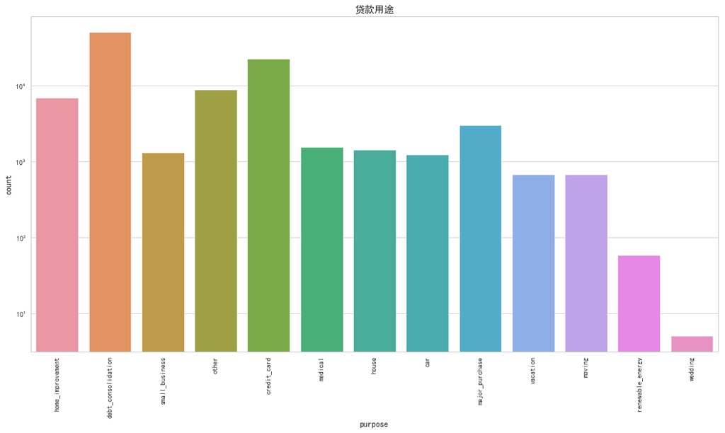

```python
plt.figure(figsize=(18,9))
cnt_plot = sns.countplot(used_data['purpose'])
cnt_plot.set(yscale='log')
plt.xticks(rotation=90)
plt.title('贷款用途')
cnt_plot.figure.savefig('Purpose')
```

平台贷款用途最多的为债务重组，其次是信用卡还债，第三是其他，第四是住房改善。一般来说前两者的客户现金流比较紧张，偿还能力弱，发生违约的可能性较高，用途为其他的贷款，需要另行分析其风险

- 5.客户信用等级占比

```python
used_data['grade'].value_counts()
```

```
B    29649
C    26255
A    24490
D    13976
E     3329
F      635
G      102
Name: grade, dtype: int64
```

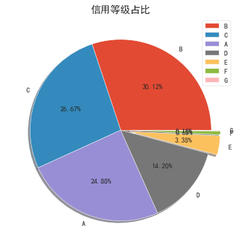

```python
loan_status_values = pd.value_counts(used_data['grade']).values
labels = ['B','C','A','D','E','F','G']
plt.figure(figsize=(6,6))
plt.pie(loan_status_values,explode = [0,0,0,0,0.1,0.1,0.1],
        labels = labels, shadow = True,autopct='%1.2f%%')
plt.title('信用等级占比')
plt.legend()
plt.show()
```

- 6.贷款利率种类分布

```python
used_data['int_rate_num'] = used_data['int_rate'].str.rstrip('%').astype('float')
used_data.tail()#检查空值，若有则删除
```

|  | loan_amnt | term | int_rate | grade | issue_d | addr_state | loan_status | purpose | delinq_2yrs | annual_inc | emp_length | loan_status_coded | int_rate_num |
| --- | --- | --- | --- | --- | --- | --- | --- | --- | --- | --- | --- | --- | --- |
| 107859 | 5000.0 | 36 months | 12.62% | C | Jan-18 | UT | Current | credit_card | 0.0 | 56000.0 | 4 years | 0 | 12.62 |
| 107860 | 6000.0 | 36 months | 10.91% | B | Jan-18 | NH | Current | debt_consolidation | 0.0 | 50000.0 | 10+ years | 0 | 10.91 |
| 107861 | 4375.0 | 36 months | 14.08% | C | Jan-18 | IL | Current | home_improvement | 0.0 | 52000.0 | 10+ years | 0 | 14.08 |
| 107862 | 12000.0 | 36 months | 10.42% | B | Jan-18 | IN | Current | debt_consolidation | 1.0 | 36000.0 | 8 years | 0 | 10.42 |
| 107863 | 14000.0 | 36 months | 13.59% | C | Jan-18 | CA | Fully Paid | car | 0.0 | 80000.0 | 2 years | 0 | 13.59 |

```python
used_data.describe()
```

|  | loan_amnt | delinq_2yrs | annual_inc | loan_status_coded | int_rate_num |
| --- | --- | --- | --- | --- | --- |
| count | 98436.000000 | 98436.000000 | 9.843600e+04 | 98436.000000 | 98436.000000 |
| mean | 16447.056717 | 0.228301 | 8.162794e+04 | 0.018144 | 12.416044 |
| std | 10248.223922 | 0.737810 | 7.906286e+04 | 0.133472 | 4.999479 |
| min | 1000.000000 | 0.000000 | 0.000000e+00 | 0.000000 | 5.310000 |
| 25% | 8500.000000 | 0.000000 | 4.800000e+04 | 0.000000 | 9.430000 |
| 50% | 14875.000000 | 0.000000 | 6.800000e+04 | 0.000000 | 11.980000 |
| 75% | 24000.000000 | 0.000000 | 9.800000e+04 | 0.000000 | 15.050000 |
| max | 40000.000000 | 20.000000 | 8.365188e+06 | 1.000000 | 30.990000 |

```
贷款利率中位数
11.98
贷款利率最小值
5.31
贷款利率最大值
30.99
```

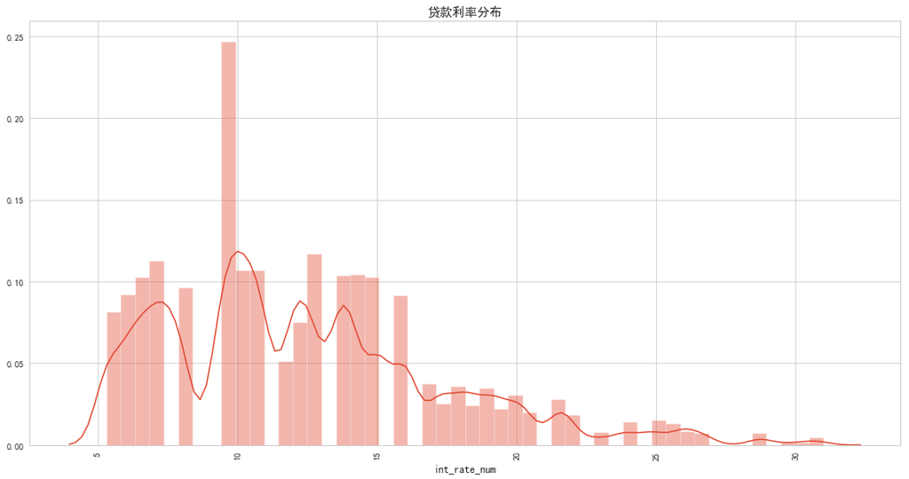

```python
plt.figure(figsize=(18,9))
sdisplot_loan = sns.distplot(used_data['int_rate_num'])
plt.xticks(rotation=90)
plt.xlabel('int_rate_num')
plt.title('贷款利率分布')
sdisplot_loan.figure.savefig('InterestRate')
print('贷款利率中位数')
print(used_data['int_rate_num'].median())
print('贷款利率最小值')
print(used_data['int_rate_num'].min())
print('贷款利率最大值')
print(used_data['int_rate_num'].max())
```

## 多维变量分析

- 1.探索贷款与时间的关系

首先对时间数据类型进行转换

```python
used_data['issue_month']=used_data['issue_d'].apply(lambda x:x[:3]).map({'Mar':'2018-03','Jan':'2018-01','Feb':'2018-02'})
```

```python
used_data.head()
```

|  | loan_amnt | term | int_rate | grade | issue_d | addr_state | loan_status | purpose | delinq_2yrs | annual_inc | emp_length | loan_status_coded | int_rate_num | issue_month |
| --- | --- | --- | --- | --- | --- | --- | --- | --- | --- | --- | --- | --- | --- | --- |
| 0 | 18500.0 | 36 months | 13.58% | C | Mar-18 | NJ | Current | home_improvement | 1.0 | 82985.0 | 6 years | 0 | 13.58 | 2018-03 |
| 1 | 7000.0 | 36 months | 7.34% | A | Mar-18 | IL | Current | debt_consolidation | 1.0 | 180700.0 | 10+ years | 0 | 7.34 | 2018-03 |
| 2 | 16000.0 | 60 months | 11.98% | B | Mar-18 | WY | Current | home_improvement | 0.0 | 95000.0 | 5 years | 0 | 11.98 | 2018-03 |
| 3 | 28000.0 | 36 months | 10.90% | B | Mar-18 | NC | Current | debt_consolidation | 0.0 | 103000.0 | 6 years | 0 | 10.90 | 2018-03 |
| 4 | 8300.0 | 36 months | 7.34% | A | Mar-18 | MO | Current | debt_consolidation | 0.0 | 40000.0 | 4 years | 0 | 7.34 | 2018-03 |

```python
loan_amount_group_by_month = used_data.groupby('issue_month')['loan_amnt'].sum()
loan_amount_group_by_month_df = pd.DataFrame(loan_amount_group_by_month).reset_index()
loan_amount_group_by_month_df
```

|  | issue_month | loan_amnt |
| --- | --- | --- |
| 0 | 2018-01 | 547292025.0 |
| 1 | 2018-02 | 493458275.0 |
| 2 | 2018-03 | 578232175.0 |

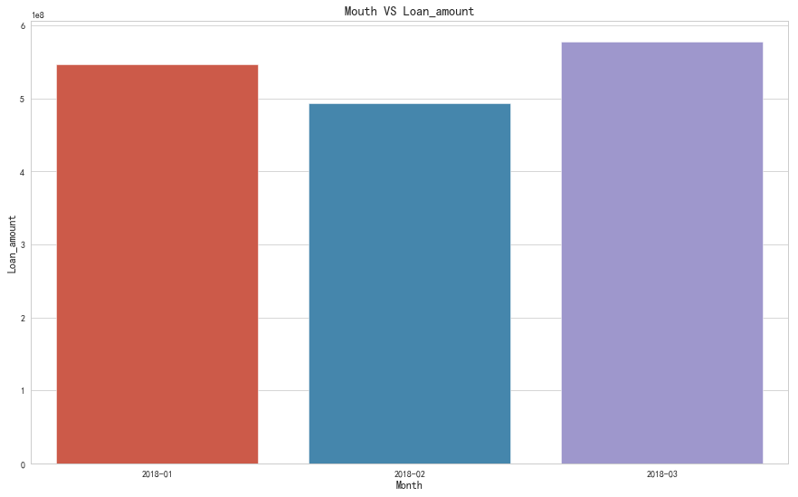

```python
plt.figure(figsize=(15,9))
plot1 = sns.barplot(x='issue_month',y='loan_amnt',data=loan_amount_group_by_month_df)
plt.xlabel('Month')
plt.ylabel('Loan_amount')
plt.title('Mouth VS Loan_amount')
plot1.figure.savefig('Month VS Loan_amount.png')
```

- 2.探索贷款金额和州之间的关系

```python
data_group_by_state = used_data.groupby(['addr_state'])['loan_amnt'].sum()
data_group_by_state_df = data_group_by_state.reset_index()
```

```python
data_group_by_state_df.head()
```

|  | addr_state | loan_amnt |
| --- | --- | --- |
| 0 | AK | 5321050.0 |
| 1 | AL | 17513275.0 |
| 2 | AR | 10711600.0 |
| 3 | AZ | 36222500.0 |
| 4 | CA | 229205825.0 |

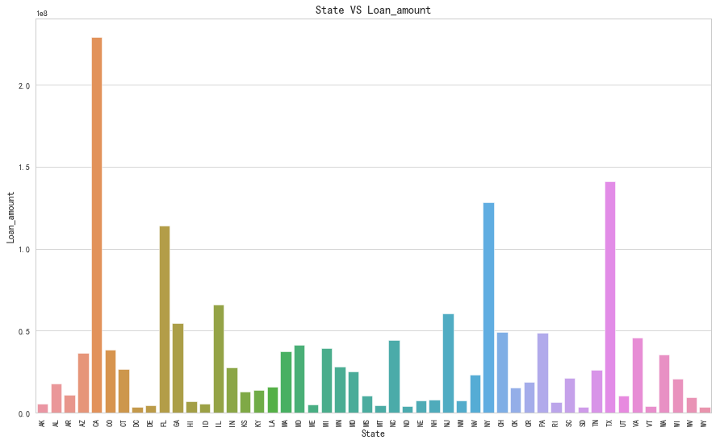

```python
plt.figure(figsize=(15,9))
plot1 = sns.barplot(x='addr_state',y='loan_amnt',data=data_group_by_state_df)
plt.xlabel('State')
plt.ylabel('Loan_amount')
plt.xticks(rotation=90)
plt.title('State VS Loan_amount')
plot1.figure.savefig('State VS Loan_amount.png')
```

查询资料知道Lending Club总部在加州，因此加州市场最好，其次是德克萨斯州和纽约州。因此，从风险防范角度看，应该重点审核这几个城市借贷人的基本信息

- 3.探索信用等级，贷款期限和利率的关系

```python
data_group_by_grade_term = used_data.groupby(['grade','term'])['int_rate_num'].mean()
data_group_by_grade_term_df = data_group_by_grade_term.reset_index()
data_group_by_grade_term_pivot = data_group_by_grade_term_df.pivot(index='grade',columns='term',values='int_rate_num')
data_group_by_grade_term_pivot
```

| term grade | 36 months | 60 months |
| --- | --- | --- |
| A | 6.734296 | 7.131188 |
| B | 10.506156 | 10.598011 |
| C | 14.200569 | 14.155105 |
| D | 19.078823 | 19.155563 |
| E | 24.374345 | 25.331816 |
| F | 29.962105 | 29.355000 |
| G | 30.870000 | 30.801340 |

```python
used_data['grade'].value_counts()#查看信用等级分布
```

```
B    29649
C    26255
A    24490
D    13976
E     3329
F      635
G      102
Name: grade, dtype: int64
```

从表格可以看出，P2P平台的利率最高档为30%，而利率最低档为7%左右，总体利率水平也相对传统银行较高。 信用评级从A到G，A的的借款人信用评分最高，财务状况较好，违约发生的可能性较低，因此利率也相对较低。

- 4.探索贷款用途和利率的关系

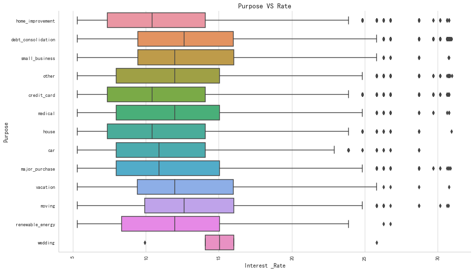

```python
plt.figure(figsize=(15,9))
plot1 = sns.boxplot(x='int_rate_num',y='purpose',data=used_data)
sns.despine(top=True)
plt.xlabel('Interest _Rate')
plt.ylabel('Purpose')
plt.xticks(rotation=90)
plt.title('Purpose VS Rate')
plot1.figure.savefig('Purpose VS Rate.png')
```

贷款用途为wedding,debt_consolidation以及moving的贷款利率最高，其中wedding用途的贷款利率最高。

- 5.探索贷款金额与利率之间的关系

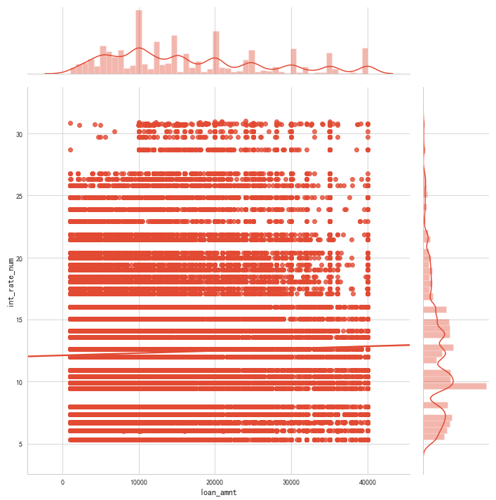

```python
plt.figure(figsize=(15,9))
j_plot = sns.jointplot('loan_amnt','int_rate_num',data=used_data,kind='reg',size=10)
j_plot.savefig('Loan Amount VS Interest Rate.png')
```

图的中间是贷款金额和利率的线性关系图，图的上方和右方分别是贷款金额和利率的分布图。我们从图中并没有发现贷款金额和贷款利率有明显的关系。

- 6.探索贷款利率与违约次数之间的关系

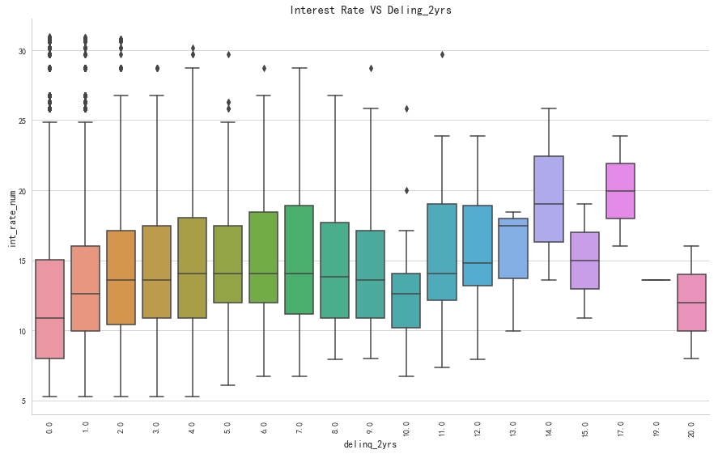

```python
plt.figure(figsize=(15,9))
plot1 = sns.boxplot(x='delinq_2yrs',y='int_rate_num',data=used_data)
sns.despine(top=True)
plt.xticks(rotation=90)
plt.title('Interest Rate VS Deling_2yrs')
plot1.figure.savefig('Purpose VS Rate.png')
```

违约次数越多的人意味着自身财务越差，还款能力也差，因此此类用户贷款风险高，对此部分应给予更高的利率定价。

- 7.探索利率、收入、工作年限以及贷款状态之间的关系

```python
used_data['emp_length'].value_counts()
```

```
10+ years    35706
2 years      10191
3 years       9179
< 1 year      7339
1 year        7169
4 years       6918
5 years       6815
6 years       4716
7 years       4002
8 years       3278
9 years       3123
Name: emp_length, dtype: int64
```

```python
mapping_dict = {
    "emp_length": {
        "10+ years": 10,
        "9 years": 9,
        "8 years": 8,
        "7 years": 7,
        "6 years": 6,
        "5 years": 5,
        "4 years": 4,
        "3 years": 3,
        "2 years": 2,
        "1 year": 1,
        "< 1 year": 0,
    }
}
used_data = used_data.replace(mapping_dict)
used_data['annual_inc'] = used_data['annual_inc'].astype('float').dropna()
```

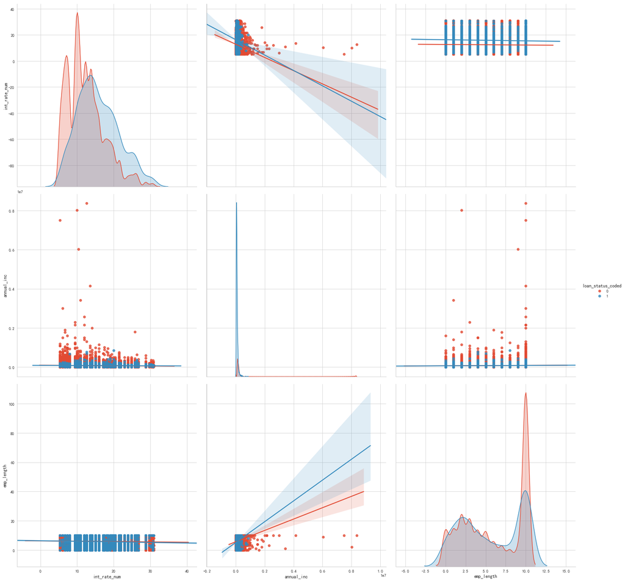

```python
p_plot = sns.pairplot(used_data,vars=['int_rate_num','annual_inc','emp_length'],hue='loan_status_coded',diag_kind='kde',kind='reg',size=7)
p_plot.savefig('Int Rate VS Annual Income VS Emp_Length')
```

## 总结

```python
used_data.corr()#计算相关系数2
```

|  | loan_amnt | delinq_2yrs | annual_inc | emp_length | loan_status_coded | int_rate_num |
| --- | --- | --- | --- | --- | --- | --- |
| loan_amnt | 1.000000 | -0.016717 | 0.259307 | 0.078747 | 0.011272 | 0.037562 |
| delinq_2yrs | -0.016717 | 1.000000 | 0.045911 | 0.022047 | 0.015810 | 0.100740 |
| annual_inc | 0.259307 | 0.045911 | 1.000000 | 0.083930 | -0.003109 | -0.080562 |
| emp_length | 0.078747 | 0.022047 | 0.083930 | 1.000000 | -0.008267 | -0.033140 |
| loan_status_coded | 0.011272 | 0.015810 | -0.003109 | -0.008267 | 1.000000 | 0.091274 |
| int_rate_num | 0.037562 | 0.100740 | -0.080562 | -0.033140 | 0.091274 | 1.000000 |

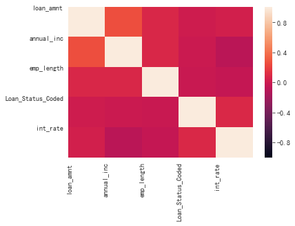

```python
# 相关系数图
used_data = used_data.drop(['delinq_2yrs'],axis=1)
names = ['loan_amnt', 'annual_inc' ,'emp_length', 'Loan_Status_Coded','int_rate' ] #设置变量名
correlations = used_data.corr()
# plot correlation matrix
plt.figure(figsize=(19, 9))
fig = plt.figure() #调用figure创建一个绘图对象
ax = fig.add_subplot(111)
cax = sns.heatmap(correlations, vmin=-1, vmax=1)  #绘制热力图，从-1到1
ticks = np.arange(0,5,1) #生成0-5，步长为1
ax.set_xticks(ticks)  #生成刻度
ax.set_yticks(ticks)
ax.set_xticklabels(names) #生成x轴标签
ax.set_yticklabels(names)
plt.xticks(rotation=90)
fig.savefig("Corr")
plt.show()
```

### 3.个人建议

- 完善客户画像和产品设计：信贷业务开展前，首先明确信贷机构的目标客户群，目标客户的特征和画像信息是什么。
- 优化贷款模型：完善客户信息的同时，借助机器学习的技术持续优化贷款模型。